[figure not shown]

# Regresión Logística

Con este notebook iniciaremos la tarea de clasificación utilizando el algoritmo de Regresión Logística. Este modelo permite estimar la probabilidad de que un registro pertenezca a una de dos clases (evento binario). A diferencia de los ejercicios anteriores, ahora no buscamos predecir un valor numérico, sino asignar una categoría.

Para esta práctica trabajaremos con un conjunto de datos relacionado con proyectos de construcción residencial, que contiene información para analizar el comportamiento de las emisiones de carbono en función de decisiones de diseño, materiales y políticas implementadas. Seguiremos una estructura similar a las prácticas anteriores: exploración, preparación de datos, construcción de un pipeline, búsqueda de hiperparámetros y evaluación.

Este material está dividido en las siguientes partes:

1. Importación de librerías.
2. Carga de los datos.
3. Exploración de los datos.
4. Limpieza y preparación inicial de los datos.
5. Partición de los datos.
6. Construcción del pipeline de procesamiento y modelado.
7. Entrenamiento del modelo de Regresión Logística con búsqueda de hiperparámetros.
8. Evaluación e interpretación del mejor modelo.
9. Persistencia del pipeline entrenado.
10. Ejercicios y profundización.

## 1. Importación de librerías

```python
import pandas as pd
import numpy as np
import matplotlib.pyplot as plt
import joblib

from IPython.display import Markdown, display

from sklearn.model_selection import train_test_split, GridSearchCV, StratifiedKFold
from sklearn.preprocessing import StandardScaler, OneHotEncoder, FunctionTransformer
from sklearn.impute import SimpleImputer
from sklearn.compose import ColumnTransformer
from sklearn.pipeline import Pipeline
from sklearn.linear_model import LogisticRegression
from sklearn.metrics import (confusion_matrix, classification_report,
                             ConfusionMatrixDisplay, accuracy_score,
                             precision_score, recall_score, f1_score)
```

## 2. Carga de los datos

Como se mencionó anteriormente, en esta práctica utilizaremos un conjunto de datos relacionado con la reducción de carbono en construcciones residenciales. A diferencia del caso anterior ahora utilizaremos un archivo separado por comas (.csv).

```python
data_CO2 = pd.read_csv('data/Policy_Driven_Carbon_Reduction_1640.csv', sep=',')
```

```python
data = data_CO2.copy()
```

El diccionario de los datos es el siguiente:

| Variable | Tipo | Descripción | Unidad | Valores / Rango sugerido |
| --- | --- | --- | --- | --- |
| Project_ID | Categórica ID | Identificador único del proyecto |  | Código alfanumérico ejemplo P0001 |
| Project_Type | Categórica nominal | Tipo de construcción residencial |  | High-rise, Mid-rise, Low-rise |
| Building_Area_m2 | Numérica continua | Área total construida | m2 | Mayor que 0 |
| Green_Certification_Level | Categórica ordinal | Nivel de certificación ambiental |  | Basic, Silver, Gold, Platinum |
| Policy_Interventions | Numérica discreta | Número de políticas ambientales implementadas | Conteo | Mayor o igual a 0 |
| Lifecycle_Phase | Categórica nominal | Fase del ciclo de vida evaluada |  | Construction, Operation, End of life, Material Production |
| Embodied_Emissions_tCO2e | Numérica continua | Emisiones incorporadas de materiales y construcción | tCO2e | Mayor o igual a 0 |
| Operational_Emissions_tCO2e | Numérica continua | Emisiones durante la operación del edificio | tCO2e | Mayor o igual a 0 |
| Supply_Chain_Emission_Share_% | Numérica continua | Porcentaje de emisiones de la cadena de suministro | Porcentaje | De 0 a 100 |
| ReadyMix_Concrete_Emission_tCO2e | Numérica continua | Emisiones asociadas al concreto premezclado | tCO2e | Mayor o igual a 0 |
| Electric_Power_Emission_tCO2e | Numérica continua | Emisiones derivadas del consumo eléctrico | tCO2e | Mayor o igual a 0 |
| Lighting_Fixture_Emission_tCO2e | Numérica continua | Emisiones asociadas a iluminación | tCO2e | Mayor o igual a 0 |
| Material_Reuse_% | Numérica continua | Porcentaje de reutilización de materiales | Porcentaje | De 0 a 100 |
| Renewable_Energy_% | Numérica continua | Porcentaje de energía renovable utilizada | Porcentaje | De 0 a 100 |
| Waste_Minimization_% | Numérica continua | Porcentaje de minimización de residuos | Porcentaje | De 0 a 100 |
| Urban_Sustainability_Score | Numérica continua | Índice de sostenibilidad urbana | Índice | Escala aproximada de 0 a 100 |
| Total_Lifecycle_Emissions_tCO2e | Numérica continua | Emisiones totales del ciclo de vida | tCO2e | Mayor o igual a 0 |
| Emission_Reduction_% | Numérica continua | Porcentaje total de reducción de emisiones | Porcentaje | De 0 a 100 |
| Emission_Reduction_Class | Categórica nominal | Categoría de reducción de emisiones |  | Low, Medium, High |

## 3. Exploración del conjunto de datos

```python
data.head()
```

|  | Project_ID | Project_Type | Building_Area_m2 | Green_Certification_Level | Policy_Interventions | Lifecycle_Phase | Embodied_Emissions_tCO2e | Operational_Emissions_tCO2e | Supply_Chain_Emission_Share_% | ReadyMix_Concrete_Emission_tCO2e | Electric_Power_Emission_tCO2e | Lighting_Fixture_Emission_tCO2e | Material_Reuse_% | Renewable_Energy_% | Waste_Minimization_% | Urban_Sustainability_Score | Total_Lifecycle_Emissions_tCO2e | Emission_Reduction_% | Emission_Reduction_Class |
| --- | --- | --- | --- | --- | --- | --- | --- | --- | --- | --- | --- | --- | --- | --- | --- | --- | --- | --- | --- |
| 0 | P0001 | High-rise | 8702 | Silver | 2 | Operation | 956.45 | 725.68 | 55.2 | 534.28 | 383.47 | 38.27 | 45.0 | 65.4 | 15.2 | 87.9 | 1682.13 | 24.8 | Medium |
| 1 | P0002 | Low-rise | 2368 | Basic | 2 | Construction | 1211.80 | 769.83 | 62.3 | 946.28 | 1035.56 | 260.64 | 16.1 | 10.3 | 2.5 | 50.3 | 1981.63 | 19.8 | Medium |
| 2 | P0003 | High-rise | 15061 | Platinum | 2 | Operation | 210.56 | 2354.05 | 78.6 | 364.31 | 355.47 | 263.17 | 32.6 | 56.7 | 2.6 | 37.3 | 2564.61 | 44.3 | High |
| 3 | P0004 | High-rise | 16012 | Platinum | 0 | Operation | 341.32 | 342.76 | 32.8 | 474.13 | 958.84 | 152.18 | 35.4 | 57.6 | 1.7 | 37.5 | 684.08 | 38.3 | High |
| 4 | P0005 | Low-rise | 15399 | Gold | 0 | End-of-life | 1786.26 | 1806.09 | 58.7 | 808.26 | 676.74 | 163.98 | 38.9 | 49.6 | 16.4 | 69.7 | 3592.35 | 28.2 | Medium |

```python
data.shape
```

```
(1640, 19)
```

```python
data.describe()
```

|  | Building_Area_m2 | Policy_Interventions | Embodied_Emissions_tCO2e | Operational_Emissions_tCO2e | Supply_Chain_Emission_Share_% | ReadyMix_Concrete_Emission_tCO2e | Electric_Power_Emission_tCO2e | Lighting_Fixture_Emission_tCO2e | Material_Reuse_% | Renewable_Energy_% | Waste_Minimization_% | Urban_Sustainability_Score | Total_Lifecycle_Emissions_tCO2e | Emission_Reduction_% |
| --- | --- | --- | --- | --- | --- | --- | --- | --- | --- | --- | --- | --- | --- | --- |
| count | 1640.000000 | 1640.000000 | 1640.000000 | 1640.000000 | 1640.000000 | 1640.000000 | 1640.000000 | 1640.000000 | 1640.000000 | 1640.000000 | 1640.000000 | 1640.000000 | 1640.000000 | 1640.000000 |
| mean | 10312.521951 | 1.960976 | 1073.873866 | 1632.026372 | 55.257622 | 548.699957 | 797.849030 | 159.191116 | 25.681890 | 35.881890 | 20.262134 | 59.028598 | 2705.900238 | 26.189573 |
| std | 5627.477838 | 1.414106 | 515.000760 | 757.602387 | 14.389729 | 264.565731 | 410.727225 | 81.079699 | 14.094244 | 20.319337 | 11.555985 | 21.817457 | 926.772210 | 12.613638 |
| min | 511.000000 | 0.000000 | 200.430000 | 300.140000 | 30.000000 | 100.140000 | 101.870000 | 20.090000 | 0.000000 | 0.000000 | 0.100000 | 20.000000 | 578.380000 | 2.000000 |
| 25% | 5554.750000 | 1.000000 | 632.937500 | 991.045000 | 42.775000 | 315.622500 | 434.992500 | 89.205000 | 14.000000 | 18.275000 | 10.575000 | 40.775000 | 2042.750000 | 16.300000 |
| 50% | 10380.500000 | 2.000000 | 1056.275000 | 1633.580000 | 55.300000 | 541.995000 | 785.610000 | 158.840000 | 26.300000 | 35.750000 | 20.300000 | 60.400000 | 2692.595000 | 25.550000 |
| 75% | 15223.250000 | 3.000000 | 1512.135000 | 2276.110000 | 67.800000 | 783.280000 | 1171.167500 | 230.037500 | 37.300000 | 53.025000 | 30.325000 | 77.900000 | 3386.572500 | 36.300000 |
| max | 19981.000000 | 4.000000 | 1998.570000 | 2996.270000 | 80.000000 | 999.400000 | 1497.620000 | 299.980000 | 50.000000 | 70.000000 | 40.000000 | 95.000000 | 4921.800000 | 55.000000 |

Veamos el comportamiento de las variables categóricas.

```python
data['Project_Type'].value_counts()
```

```
Project_Type
Low-rise     569
High-rise    536
Mid-rise     535
Name: count, dtype: int64
```

También lo podemos ver para la fila de `Green_Certification_Level`

```python
data['Green_Certification_Level'].value_counts()
```

```
Green_Certification_Level
Silver      380
Gold        360
Basic       352
Platinum    228
Name: count, dtype: int64
```

La variable de `Lifecycle_Phase`, también categórica:

```python
data['Lifecycle_Phase'].value_counts()
```

```
Lifecycle_Phase
Construction           428
Operation              415
Material Production    404
End-of-life            393
Name: count, dtype: int64
```

Al igual que para la variable `Emission_Reduction_Class`:

```python
data['Emission_Reduction_Class'].value_counts()
```

```
Emission_Reduction_Class
Medium    826
High      458
Low       356
Name: count, dtype: int64
```

Algo que también podemos hacer en esta etapa es verificar si la variable `Project_ID` tiene valores únicos, es decir, que cada registro tiene un identificador distinto:

```python
data["Project_ID"].is_unique
```

```
True
```

## 4. Limpieza y preparación inicial de los datos

Verificación de ausencias:

Además de identificar cuántos valores faltan, es importante decidir **cómo se tratarán**. Esta decisión debe realizarse utilizando únicamente la información del conjunto de entrenamiento; por ello, cuando una imputación requiere aprender algún valor de los datos, debe incorporarse al pipeline.

```python
data.isna().sum()
```

```
Project_ID                            0
Project_Type                          0
Building_Area_m2                      0
Green_Certification_Level           320
Policy_Interventions                  0
Lifecycle_Phase                       0
Embodied_Emissions_tCO2e              0
Operational_Emissions_tCO2e           0
Supply_Chain_Emission_Share_%         0
ReadyMix_Concrete_Emission_tCO2e      0
Electric_Power_Emission_tCO2e         0
Lighting_Fixture_Emission_tCO2e       0
Material_Reuse_%                      0
Renewable_Energy_%                    0
Waste_Minimization_%                  0
Urban_Sustainability_Score            0
Total_Lifecycle_Emissions_tCO2e       0
Emission_Reduction_%                  0
Emission_Reduction_Class              0
dtype: int64
```

Verificación de duplicados:

```python
data.duplicated().sum()
```

```
np.int64(0)
```

Por otra parte, desde la perspectiva del negocio, el interés principal no es diferenciar entre tres niveles de reducción de emisiones (Low, Medium y High), sino identificar con claridad qué proyectos logran una reducción alta y cuáles no. Esta distinción permite tomar decisiones estratégicas más directas, como priorizar incentivos, monitorear cumplimiento de metas ambientales o enfocar recursos en proyectos con mayor impacto.

Por ello, se decidió agrupar las categorías Low y Medium en una sola clase y mantener High como la categoría de interés. De esta manera, el problema se redefine en términos operativos simples y alineados con los objetivos estratégicos: proyectos con reducción alta versus proyectos sin reducción alta.

```python
data['Emission_Reduction_Bin'] = np.where(data['Emission_Reduction_Class'].isin(['Low', 'Medium']),0,1)

data['Emission_Reduction_Bin'].value_counts()
```

```
Emission_Reduction_Bin
0    1182
1     458
Name: count, dtype: int64
```

## 5. Partición de los datos

```python
X = data.drop(columns=['Emission_Reduction_Bin'])
y = data['Emission_Reduction_Bin']
```

```python
X_train, X_test, y_train, y_test = train_test_split(X, y, test_size=0.2, random_state=1, stratify=y)
```

Para manterner la misma proporción de las clases en ambos conjuntos se utiliza la opción `stratify=y`.

```python
X_train.shape, X_test.shape
```

```
((1312, 19), (328, 19))
```

## 6. Construcción del pipeline

Recordemos que en el pipeline debemos incluir todas las transformaciones y procesos de limpieza y preparación que se ajustan con los datos de entrenamiento y que luego deben aplicarse de manera consistente al conjunto de prueba o a nuevos datos.

El primer paso consiste en eliminar las columnas que no serán utilizadas en el modelo. Incluir esta operación dentro del flujo de trabajo garantiza que la misma depuración se aplique automáticamente cuando el pipeline procese nuevos datos. En este caso, se excluye `Project_ID` porque corresponde a un identificador y no aporta información predictiva. Asimismo, se elimina `Emission_Reduction_Class`, ya que su información está representada en la variable agrupada y codificada `Emission_Reduction_Bin`, que será la variable objetivo del modelo. Finalmente, se descarta `Emission_Reduction_%`, puesto que, según los expertos del dominio, esta variable fue utilizada para generar la clase, lo que podría introducir fuga de información (data leakage) en el proceso de modelado.

```python
cols_to_drop = ['Project_ID', 'Emission_Reduction_%', 'Emission_Reduction_Class']

def drop_columns(df):
    return df.drop(columns=cols_to_drop, errors="ignore")

dropper = FunctionTransformer(drop_columns)
```

Una vez definido el primer paso, es necesario separar las columnas según su tipo de dato. Esta distinción es fundamental, ya que las transformaciones aplicadas a variables numéricas son diferentes de las que se emplean para variables categóricas.

```python
numericas_features = ['Building_Area_m2', 'Policy_Interventions', 'Embodied_Emissions_tCO2e', 'Operational_Emissions_tCO2e', 'Supply_Chain_Emission_Share_%', 'ReadyMix_Concrete_Emission_tCO2e', 'Electric_Power_Emission_tCO2e', 'Lighting_Fixture_Emission_tCO2e', 'Material_Reuse_%', 'Renewable_Energy_%', 'Waste_Minimization_%', 'Urban_Sustainability_Score', 'Total_Lifecycle_Emissions_tCO2e']
categoricas_features = ['Project_Type', 'Green_Certification_Level', 'Lifecycle_Phase']
```

Ya con las variables separadas según su tipo de dato, estableceremos las transformaciones para cada grupo.

Para las variables numéricas utilizaremos `StandardScaler()`. La estandarización es especialmente relevante cuando empleamos regularización, porque hace que la penalización actúe sobre coeficientes asociados a variables en escalas comparables.

```python
numerica_transformer = Pipeline(steps=[
    ('imputador', SimpleImputer(strategy='median')),
    ('scaler', StandardScaler())
])
```

Para las variables categóricas construiremos otro pequeño pipeline. Primero, los valores ausentes se representarán explícitamente mediante la categoría `Sin información`. Después aplicaremos `OneHotEncoder()`.

Usaremos `drop='first'` para dejar una categoría como referencia en cada variable categórica. Esto facilita posteriormente la interpretación de los coeficientes del modelo. `handle_unknown='ignore'` permite que el pipeline procese categorías nuevas que aparezcan en datos futuros.

```python
categorica_transformer = Pipeline(steps=[
    ('imputador', SimpleImputer(
        strategy='constant',
        fill_value='Sin información'
    )),
    ('onehot', OneHotEncoder(
        handle_unknown='ignore',
        drop='first'
    ))
])
```

Ya con las transformaciones definidas usamos un `ColumnTransformer()` para aplicar los pasos que definimos anteriormente según el tipo de variable. Lo que se busca es dejar explícito al modelo las transformaciones que debe usar con las variables numéricas y las de las variables categóricas.

```python
preprocesador = ColumnTransformer(
    transformers=[
        ('num', numerica_transformer, numericas_features),
        ('cat', categorica_transformer, categoricas_features)
    ]
)
```

Una vez definido el preprocesador, procedemos a establecer la secuencia completa del pipeline. Para ello, configuramos pipeline_rl, que encadena de manera ordenada todas las transformaciones que se aplicarán al conjunto de entrenamiento, junto con el modelo. De esta forma, garantizamos que exactamente los mismos pasos se ejecuten posteriormente cuando el pipeline procese el conjunto de test o nuevos datos en producción.

Es importante notar que `LogisticRegression()` incluye varios hiperparámetros. En este caso, se define `max_iter=1000`, que establece el número máximo de iteraciones permitidas para que el algoritmo converja; este valor puede ajustarse según la complejidad del problema y la estabilidad del proceso de optimización.

```python
pipeline_rl = Pipeline(steps=[
    ('dropper', dropper),
    ('preprocesador', preprocesador),
    ('modelo', LogisticRegression(
        max_iter=1000,
     ))
])
```

## 7. Entrenamiento del modelo de Regresión Logística con búsqueda de hiperparámetros

### ¿Por qué "logística"? La función sigmoide

La regresión logística toma la misma combinación lineal de variables que la regresión lineal ($z = w_0 + w_1 x_1 + \cdots + w_m x_m$) y la pasa por la **función sigmoide**, que convierte cualquier número real en una probabilidad entre 0 y 1:

$$\sigma(z) = \frac{1}{1 + e^{-z}}$$

La sigmoide convierte cualquier valor real en un número entre 0 y 1, que puede interpretarse como $P(\text{clase} = 1 \mid x)$. Si supera un umbral (típicamente 0.5), el modelo predice la clase positiva; si no, predice la negativa.

> **Una precisión importante:** aunque la salida pase por una función no lineal, la frontera de decisión de la regresión logística es lineal con respecto a las características que recibe el modelo, a menos que previamente incorporemos transformaciones no lineales.

#### Hiperparámetros clave de LogisticRegression

| Hiperparámetro | Efecto |
| --- | --- |
| `C` | Inverso de la regularización. C pequeño → más regularización → coeficientes más pequeños. C grande → menos regularización → más riesgo de sobreajuste. |
| `penalty` | Tipo de regularización: `l2` nunca lleva coeficientes a 0; `l1` puede llevarlos exactamente a 0 (selección de variables automática). |
| `solver` | Algoritmo de optimización. No todos son compatibles con todas las penalizaciones (ver listas separadas en `param_grid`). |

```python
param_grid = [
    # Combinaciones válidas con L2
    {
        'modelo__penalty': ['l2'],
        'modelo__solver': ['newton-cg', 'lbfgs', 'liblinear'],
        'modelo__C': [0.1, 0.2, 0.5, 0.8, 1]
    },
    # Combinaciones válidas con L1
    {
        'modelo__penalty': ['l1'],
        'modelo__solver': ['liblinear'],
        'modelo__C': [0.1, 0.2, 0.5, 0.8, 1]
    }
]
```

Como se trata de un problema de clasificación, utilizaremos `StratifiedKFold`. A diferencia de una partición K-Fold general, esta estrategia procura mantener aproximadamente la proporción de las clases en cada fold. Usaremos 10 folds y mezclaremos las observaciones antes de crear las particiones.

```python
kfold = StratifiedKFold(n_splits=10, shuffle=True, random_state=0)
```

Ahora procedemos a realizar la búsqueda de hiperparámetros utilizando `GridSearchCV()` sobre el espacio de parámetros definido previamente. Para orientar la selección del mejor modelo emplearemos como métrica el F1-score.

El `F1-score` es la media armónica entre precisión (precision) y sensibilidad (recall), lo que permite equilibrar ambos criterios en una sola medida. Mientras la precisión indica qué proporción de las predicciones positivas es correcta, el recall mide qué proporción de los casos positivos reales fue correctamente identificada por el modelo. Se utiliza especialmente en problemas de clasificación con clases desbalanceadas, ya que la exactitud (accuracy) puede resultar engañosa cuando una clase domina el conjunto de datos.

```python
grid_rl = GridSearchCV(estimator=pipeline_rl, param_grid=param_grid, cv=kfold, scoring='f1', n_jobs=-1)
```

```python
grid_rl.fit(X_train, y_train)
```

```
GridSearchCV(cv=StratifiedKFold(n_splits=10, random_state=0, shuffle=True),
             estimator=Pipeline(steps=[('dropper',
                                        FunctionTransformer(func=<function drop_columns at 0x00000299E72387C0>)),
                                       ('preprocesador',
                                        ColumnTransformer(transformers=[('num',
                                                                         Pipeline(steps=[('imputador',
                                                                                          SimpleImputer(strategy='median')),
                                                                                         ('scaler',
                                                                                          StandardScaler())]),
                                                                         ['Building_Area_m2',
                                                                          '...
                                                                         ['Project_Type',
                                                                          'Green_Certification_Level',
                                                                          'Lifecycle_Phase'])])),
                                       ('modelo',
                                        LogisticRegression(max_iter=1000))]),
             n_jobs=-1,
             param_grid=[{'modelo__C': [0.1, 0.2, 0.5, 0.8, 1],
                          'modelo__penalty': ['l2'],
                          'modelo__solver': ['newton-cg', 'lbfgs',
                                             'liblinear']},
                         {'modelo__C': [0.1, 0.2, 0.5, 0.8, 1],
                          'modelo__penalty': ['l1'],
                          'modelo__solver': ['liblinear']}],
             scoring='f1')
```

Veamos los resultados obtenidos en la búsqueda:

```python
print("Mejores hiperparámetros:", grid_rl.best_params_)
print("Mejor puntaje medio en CV (f1):", grid_rl.best_score_)
```

```
Mejores hiperparámetros: {'modelo__C': 0.8, 'modelo__penalty': 'l2', 'modelo__solver': 'liblinear'}
Mejor puntaje medio en CV (f1): 0.950551735688722
```

Además, podemos obtener un reporte del desempeño de cada combinación de hiperparámetros evaluada mediante validación cruzada.

```python
resultados = pd.DataFrame(grid_rl.cv_results_)
cols = [
    'param_modelo__penalty',
    'param_modelo__solver',
    'param_modelo__C',
    'mean_test_score',
    'std_test_score',
    'rank_test_score'
]
summary = resultados[cols].sort_values(by='rank_test_score')
print(summary.to_string())
```

```
   param_modelo__penalty param_modelo__solver  param_modelo__C  mean_test_score  std_test_score  rank_test_score
11                    l2            liblinear              0.8         0.950552        0.019676                1
8                     l2            liblinear              0.5         0.950513        0.020691                2
13                    l2                lbfgs              1.0         0.950474        0.018535                3
10                    l2                lbfgs              0.8         0.950474        0.018535                3
14                    l2            liblinear              1.0         0.950440        0.017640                5
18                    l1            liblinear              0.8         0.950129        0.017086                6
9                     l2            newton-cg              0.8         0.949177        0.017330                7
12                    l2            newton-cg              1.0         0.949177        0.017330                7
19                    l1            liblinear              1.0         0.948833        0.016862                9
17                    l1            liblinear              0.5         0.948603        0.020372               10
16                    l1            liblinear              0.2         0.948131        0.027911               11
7                     l2                lbfgs              0.5         0.948032        0.018091               12
4                     l2                lbfgs              0.2         0.947995        0.020134               13
3                     l2            newton-cg              0.2         0.947995        0.020134               13
6                     l2            newton-cg              0.5         0.946736        0.017727               15
15                    l1            liblinear              0.1         0.946685        0.027689               16
1                     l2                lbfgs              0.1         0.945105        0.024731               17
0                     l2            newton-cg              0.1         0.945105        0.024731               17
5                     l2            liblinear              0.2         0.942297        0.024019               19
2                     l2            liblinear              0.1         0.937368        0.027365               20
```

```python
best_model = grid_rl.best_estimator_
```

## 8. Evaluación del mejor modelo

Aplicamos el pipeline completo al conjunto de prueba. El modelo fue reentrenado automáticamente con la mejor configuración encontrada por `GridSearchCV` (gracias al parámetro `refit=True` por defecto).

```python
y_pred_best = best_model.predict(X_test)
```

Ya con las predicciones hechas, es momento de ver el reporte de clasificación y los resultados obtenidos por el mejor modelo:

```python
print(classification_report(y_test, y_pred_best, target_names=['Low/Medium', 'High']))
```

```
              precision    recall  f1-score   support

  Low/Medium       0.96      0.98      0.97       236
        High       0.94      0.89      0.92        92

    accuracy                           0.95       328
   macro avg       0.95      0.94      0.94       328
weighted avg       0.95      0.95      0.95       328
```

Interpreta el reporte anterior considerando:

- **Precision** de cada clase: de las predicciones que el modelo hizo para esa clase, ¿cuántas acertó?
- **Recall** de cada clase: de todos los casos reales de esa clase, ¿cuántos detectó el modelo?
- **F1-score**: media armónica de ambas métricas — útil cuando hay desbalance.
- **Macro avg**: promedio simple entre clases (mismo peso para `Low/Medium` y `High`).
- **Weighted avg**: promedio ponderado por soporte — más influenciado por la clase mayoritaria.

> Si el macro avg y el weighted avg son similares, el modelo tiene rendimiento consistente entre clases a pesar del desbalance.

La matriz de confusión correspondiente es:

```python
matriz_confusion = confusion_matrix(y_test, y_pred_best)
print(matriz_confusion)
```

```
[[231   5]
 [ 10  82]]
```

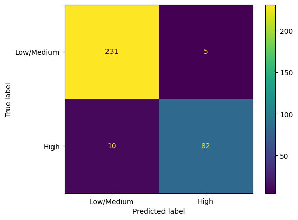

```python
ConfusionMatrixDisplay.from_predictions(y_test, y_pred_best, display_labels=['Low/Medium', 'High'])
plt.show()
```

Identifica en la matriz:

- **Verdaderos positivos (VP)**: esquina inferior derecha — `High` predicho como `High`.
- **Falsos negativos (FN)**: fila `High`, columna `Low/Medium` — proyectos de alta reducción que el modelo clasifica como bajos.
- **Falsos positivos (FP)**: fila `Low/Medium`, columna `High` — proyectos de baja reducción clasificados como altos.

En el contexto del negocio, los **falsos negativos** son especialmente costosos: un proyecto con alta reducción real que el modelo no detecta puede quedar sin el incentivo o seguimiento que merece.

El modelo presenta un desempeño muy alto en ambas clases, especialmente en `Low/Medium`, donde el número de errores es mínimo. Sin embargo, en la clase High se observa una mayor cantidad de falsos negativos (10 casos), lo que indica que algunos ejemplos de esta categoría no están siendo detectados.

Por otro lado, con fines de interpretar con mayor profundidad el modelo, podemos revisar los coeficientes, para ello debemos inicialmente sacar el preprocesador y el modelo:

```python
preprocesador_fit = best_model.named_steps['preprocesador']
log_reg_fit = best_model.named_steps['modelo']
```

```python
feature_names_num = preprocesador_fit.transformers_[0][2]

cat_pipeline_fit = preprocesador_fit.transformers_[1][1]
ohe = cat_pipeline_fit.named_steps['onehot']
feature_names_cat = ohe.get_feature_names_out(
    preprocesador_fit.transformers_[1][2]
)

all_feature_names = np.concatenate([feature_names_num, feature_names_cat])
```

Por último, obtenemos y ordenamos los coeficientes de la regresión logística:

```python
coefs = log_reg_fit.coef_[0]
coef_df = pd.DataFrame({'feature': all_feature_names, 'coef': coefs})

coef_df = coef_df.sort_values('coef', ascending=False)
coef_df.head(30)
```

|  | feature | coef |
| --- | --- | --- |
| 16 | Green_Certification_Level_Platinum | 7.417324 |
| 15 | Green_Certification_Level_Gold | 4.417885 |
| 1 | Policy_Interventions | 1.370058 |
| 8 | Material_Reuse_% | 0.146513 |
| 6 | Electric_Power_Emission_tCO2e | 0.103512 |
| 14 | Project_Type_Mid-rise | 0.078139 |
| 11 | Urban_Sustainability_Score | 0.074362 |
| 0 | Building_Area_m2 | 0.053465 |
| 7 | Lighting_Fixture_Emission_tCO2e | 0.050575 |
| 5 | ReadyMix_Concrete_Emission_tCO2e | 0.047114 |
| 3 | Operational_Emissions_tCO2e | 0.004969 |
| 12 | Total_Lifecycle_Emissions_tCO2e | -0.008365 |
| 10 | Waste_Minimization_% | -0.017148 |
| 4 | Supply_Chain_Emission_Share_% | -0.021460 |
| 2 | Embodied_Emissions_tCO2e | -0.022284 |
| 9 | Renewable_Energy_% | -0.081341 |
| 13 | Project_Type_Low-rise | -0.123570 |
| 19 | Lifecycle_Phase_End-of-life | -0.171651 |
| 20 | Lifecycle_Phase_Material Production | -0.219085 |
| 21 | Lifecycle_Phase_Operation | -0.284971 |
| 18 | Green_Certification_Level_Sin información | -1.861827 |
| 17 | Green_Certification_Level_Silver | -1.984709 |

#### Interpretación de coeficientes

Los coeficientes de una regresión logística no representan directamente un cambio en la probabilidad. Técnicamente, actúan sobre los *log-odds* de pertenecer a la clase positiva (`High`). Para una primera interpretación podemos centrarnos en su signo:

- un coeficiente **positivo** desplaza la predicción hacia la clase `High`, manteniendo las demás variables constantes;
- un coeficiente **negativo** la desplaza en sentido contrario.

En las variables numéricas, como aplicamos `StandardScaler`, un cambio de una unidad después de la transformación corresponde a una desviación estándar de la variable original. Esto hace que sus coeficientes estén expresados en una escala comparable.

Para las variables categóricas usamos `OneHotEncoder(drop='first')`. Por tanto, el coeficiente asociado a cada categoría debe interpretarse en comparación con la categoría de referencia omitida por el encoder, manteniendo las demás variables constantes.

> **Regularización:** si el mejor modelo usa `penalty='l1'`, algunos coeficientes pueden quedar exactamente en cero. Esto significa que, para esa configuración y considerando conjuntamente las demás características, el modelo no necesitó esas variables para construir la predicción. Con `l2`, los coeficientes suelen reducirse pero no quedar exactamente en cero.

Al revisar la tabla de coeficientes, evita interpretar automáticamente el coeficiente de mayor magnitud como **la variable más importante**. Los coeficientes describen la contribución estimada dentro de este modelo y dependen de las demás variables incluidas, de la codificación y de la regularización.

Para las variables numéricas, observa cuáles tienen coeficientes positivos y negativos y recuerda que corresponden a cambios de una desviación estándar. Para las variables categóricas, identifica primero la categoría de referencia antes de establecer comparaciones.

**Pregunta de reflexión:** ¿qué características parecen desplazar con mayor fuerza la predicción hacia `High`? ¿La interpretación es coherente con el contexto del problema? Formula la respuesta como una asociación encontrada por el modelo, no como una relación causal.

### Curva ROC y AUC

Para clasificación binaria, la **curva ROC** (Receiver Operating Characteristic) es una herramienta fundamental que va más allá de las métricas de un umbral fijo (0.5). Grafica la tasa de verdaderos positivos (TPR = Recall) contra la tasa de falsos positivos (FPR) para **todos los posibles umbrales de clasificación**, mostrando el compromiso entre detectar más positivos reales y generar más falsas alarmas.

El **área bajo la curva (AUC)** resume esa curva en un número: 1.0 es perfecto, 0.5 es aleatorio (la diagonal). Un AUC de 0.9 significa que, ante un positivo y un negativo aleatorios, el modelo asigna mayor probabilidad al positivo el 90% de las veces.

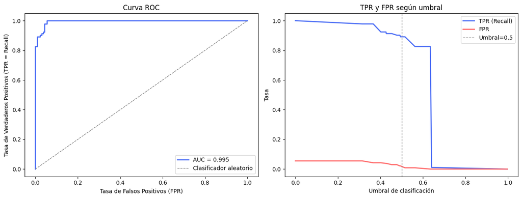

```
AUC: 0.9950

 Un AUC cercano a 1 indica que el modelo separa bien las dos clases.
   Un AUC de 0.5 significa que el modelo no es mejor que adivinar al azar.
```

```python
from sklearn.metrics import roc_curve, auc

# Probabilidades predichas para la clase positiva (High = 1)
y_prob = best_model.predict_proba(X_test)[:, 1]

fpr, tpr, thresholds = roc_curve(y_test, y_prob)
roc_auc = auc(fpr, tpr)

fig, axes = plt.subplots(1, 2, figsize=(13, 5))

# Curva ROC
axes[0].plot(fpr, tpr, color='#4C6EF5', lw=2, label=f'AUC = {roc_auc:.3f}')
axes[0].plot([0, 1], [0, 1], color='gray', linestyle='--', lw=1, label='Clasificador aleatorio')
axes[0].set_xlabel('Tasa de Falsos Positivos (FPR)')
axes[0].set_ylabel('Tasa de Verdaderos Positivos (TPR = Recall)')
axes[0].set_title('Curva ROC')
axes[0].legend()

# Umbral vs TPR/FPR — muestra el compromiso de cada umbral
axes[1].plot(thresholds[1:], tpr[:-1], color='#4C6EF5', lw=2, label='TPR (Recall)')
axes[1].plot(thresholds[1:], fpr[:-1], color='#FF6B6B', lw=2, label='FPR')
axes[1].axvline(0.5, color='gray', linestyle='--', lw=1, label='Umbral=0.5')
axes[1].set_xlabel('Umbral de clasificación')
axes[1].set_ylabel('Tasa')
axes[1].set_title('TPR y FPR según umbral')
axes[1].legend()

plt.tight_layout()
plt.show()

print(f"AUC: {roc_auc:.4f}")
print(f"\n Un AUC cercano a 1 indica que el modelo separa bien las dos clases.")
print(f"   Un AUC de 0.5 significa que el modelo no es mejor que adivinar al azar.")
```

#### Ejercicio

1. Mueve el umbral de clasificación a 0.3 (en vez de 0.5). ¿Qué sucede con el recall de la clase `High`? ¿Y con la tasa de falsos positivos? Verifica tu respuesta recalculando las métricas.

```
y_pred_umbral = (y_prob >= 0.3).astype(int)
print(classification_report(
    y_test,
    y_pred_umbral,
    target_names=['Low/Medium', 'High']
))
```

2. ¿Por qué ROC-AUC puede aportar información adicional a `accuracy` cuando las clases están desbalanceadas? ¿Qué ventaja tiene evaluar el modelo a través de múltiples umbrales en lugar de observar únicamente el umbral 0.5?

```python
# Punto 1: comparar diferentes umbrales
y_prob = best_model.predict_proba(X_test)[:, 1]

for umbral in [0.3, 0.5, 0.7]:
    y_pred_u = (y_prob >= umbral).astype(int)

    rep = classification_report(
        y_test,
        y_pred_u,
        target_names=['Low/Medium', 'High'],
        output_dict=True,
        zero_division=0
    )

    cm = confusion_matrix(y_test, y_pred_u)
    tn, fp, fn, tp = cm.ravel()
    fpr_umbral = fp / (fp + tn)

    print(
        f"Umbral={umbral:.1f} | "
        f"Recall High={rep['High']['recall']:.3f} | "
        f"FPR={fpr_umbral:.3f}"
    )

# Punto 2 — responde como comentario:
# ROC-AUC aporta información adicional porque...
```

```
Umbral=0.3 | Recall High=1.000 | FPR=0.055
Umbral=0.5 | Recall High=0.891 | FPR=0.021
Umbral=0.7 | Recall High=0.761 | FPR=0.000
```

#### Comparación de rendimientos sobre entrenamiento y test

```python
# Predicciones del mejor modelo
y_train_pred_best = best_model.predict(X_train)
y_test_pred_best  = best_model.predict(X_test)

# Métricas en train
accuracy_train  = accuracy_score(y_train, y_train_pred_best)
recall_train    = recall_score(y_train, y_train_pred_best)
precision_train = precision_score(y_train, y_train_pred_best)
f1_train        = f1_score(y_train, y_train_pred_best)

# Métricas en test
accuracy_test  = accuracy_score(y_test, y_test_pred_best)
recall_test    = recall_score(y_test, y_test_pred_best)
precision_test = precision_score(y_test, y_test_pred_best)
f1_test        = f1_score(y_test, y_test_pred_best)

# Tabla en Markdown
texto = "\n\n"
texto += "|Métrica|Train|Test|\n"
texto += "|-------|-----|----|\n"
texto += f"|Exactitud|{accuracy_train:.2%}|{accuracy_test:.2%}|\n"
texto += f"|Sensibilidad (recall)|{recall_train:.2%}|{recall_test:.2%}|\n"
texto += f"|Precisión|{precision_train:.2%}|{precision_test:.2%}|\n"
texto += f"|F1-Score|{f1_train:.2%}|{f1_test:.2%}|\n"

display(Markdown(texto))
```

| Métrica | Train | Test |
| --- | --- | --- |
| Exactitud | 97.48% | 95.43% |
| Sensibilidad (recall) | 94.81% | 89.13% |
| Precisión | 96.12% | 94.25% |
| F1-Score | 95.46% | 91.62% |

Compara las métricas de entrenamiento y prueba. Si son relativamente cercanas, esto aporta evidencia de que el modelo mantiene un comportamiento similar sobre datos no utilizados durante el ajuste. Una diferencia considerable, especialmente si el desempeño de entrenamiento es mucho mayor, puede ser una señal de sobreajuste.

Presta especial atención al **recall de la clase `High`**, porque indica qué proporción de los proyectos realmente `High` logra detectar el modelo. La elección de la métrica prioritaria depende del costo de los distintos tipos de error en el problema; no debe decidirse únicamente por cuál produce el valor numérico más alto.

Recuerda también que el desbalance de clases puede hacer que `accuracy` oculte diferencias importantes entre el desempeño de cada clase. Por esa razón conviene analizar conjuntamente matriz de confusión, precision, recall y F1-score.

## 9. Persistencia del pipeline entrenado.

Esta sección introduce un aspecto nuevo con respecto a las prácticas anteriores: aprenderemos cómo persistir modelos entrenados con scikit-learn utilizando la librería joblib, la cual permite almacenar objetos de Python en archivos para su uso posterior en producción o despliegue. Para crear el archivo se emplea la función dump(), donde se debe indicar el objeto que se desea guardar (por ejemplo, el modelo o el pipeline completo) y el nombre del archivo en el que será almacenado:

```python
joblib.dump(best_model, "modelo_regresion_logistica.joblib")
```

```
['modelo_regresion_logistica.joblib']
```

En caso de que queramos cargarlo luego usamos la función `load()`:

```python
modelo_cargado = joblib.load("modelo_regresion_logistica.joblib")
```

## 10. Ejercicios

**Ejercicio 1**. Incorpora el parámetro `class_weight='balanced'` en el modelo de regresión logística dentro del pipeline, con el fin de compensar el posible desbalance entre clases. Entrena nuevamente el modelo utilizando `GridSearchCV` y evalúa su desempeño en el conjunto de test. Compara las métricas obtenidas con las del modelo original. ¿Se observa una mejora en el recall de la clase minoritaria?

**Ejercicio 2**. Retoma la variable original `Emission_Reduction_Class` con sus tres categorías (Low, Medium, High) y entrena un modelo de regresión logística multinomial, con búsqueda de hiperparámetros explorando diferentes valores de regularización `C`. Evalúa el modelo en el conjunto de prueba. ¿Se mantiene el desempeño en todas las clases? ¿Cuál es la más difícil de predecir?

**Profundización opcional — Validación cruzada anidada.** La siguiente celda implementa una **validación cruzada anidada** (*Nested Cross-Validation*), que es la forma más rigurosa de estimar simultáneamente el rendimiento de un modelo y sus hiperparámetros óptimos, sin contaminar la evaluación con el proceso de búsqueda.

En la CV simple que usamos en este notebook, `GridSearchCV` selecciona hiperparámetros y los evalúa sobre el mismo conjunto de validación cruzada → puede dar una estimación optimista del rendimiento. La CV anidada tiene un **bucle externo** (estima el rendimiento real) y un **bucle interno** (selecciona hiperparámetros). ¿La estimación anidada es mejor o peor que la que reportó `grid_rl.best_score_`? ¿Por qué?

```python
from sklearn.model_selection import cross_val_score

# PROFUNDIZACIÓN OPCIONAL: Nested Cross-Validation
# Bucle externo: 5-fold estratificado para estimar el rendimiento
# Bucle interno: GridSearchCV con 5-fold estratificado para elegir hiperparámetros
outer_cv = StratifiedKFold(n_splits=5, shuffle=True, random_state=1)
inner_cv = StratifiedKFold(n_splits=5, shuffle=True, random_state=2)

grid_inner = GridSearchCV(
    estimator=pipeline_rl,
    param_grid=param_grid,
    cv=inner_cv,
    scoring='f1',
    n_jobs=-1
)

nested_scores = cross_val_score(
    grid_inner,
    X_train,
    y_train,
    cv=outer_cv,
    scoring='f1',
    n_jobs=-1
)

print(f"F1 en cada fold externo: {nested_scores.round(4)}")
print(f"F1 promedio (Nested CV): {nested_scores.mean():.4f} ± {nested_scores.std():.4f}")
print(f"F1 best_score_ (CV simple): {grid_rl.best_score_:.4f}")
print()
print('Compara ambas estimaciones. ¿Son similares o la CV simple resulta algo más optimista?')
```

```
F1 en cada fold externo: [0.9437 0.9306 0.9306 0.951  0.9664]
F1 promedio (Nested CV): 0.9445 ± 0.0135
F1 best_score_ (CV simple): 0.9506

Compara ambas estimaciones. ¿Son similares o la CV simple resulta algo más optimista?
```